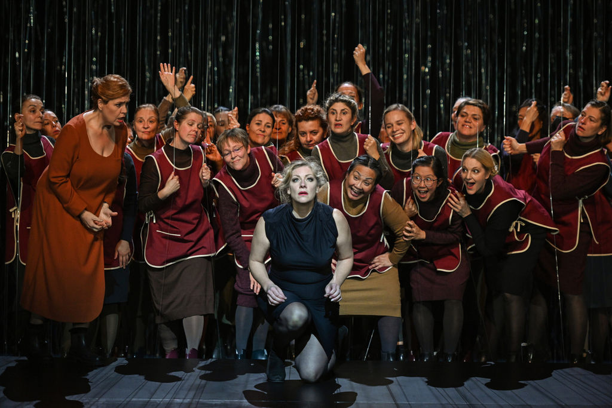

# Pressestimmen Der fliegende Holländer — „Faszination eines Psychothrillers“

Veröffentlicht: 28. Oktober 2022

Keine Kommentare

*Am 23. Oktober hatte die Neuinszenierung von Richard Wagners „Der fliegende Holländer“ Premiere. Die Musikalische Leitung lag bei Kent Nagano, Regie führte Michael Thalheimer. Ihr Rollendebüt gibt Jennifer Holloway als Senta. Als Holländer ist Thomas J. Mayer zu erleben. Kwangchul Youn ist Daland, Benjamin Bruns ist Erik. Noch bis zum 13. November ist die Premierenserie zu erleben.*

Das schrieben Medienvertreter*innen zur Premiere von „Der fliegende Holländer“:

Die dpa fasst die Premiere als „ein packender Abend mit Zündstoff“ zusammen. Die Welt titelt „Wagner als Wohltat“. Joachim Lange berichtet für Opern.News aus Wien über die Inszenierung: „Michael Thalmeimers Inszenierung von Wagners «Fliegendem Holländer» entfaltet die Faszination eines Psychothrillers, Kent Nagano interpretiert das Werk außergewöhnlich“. Weiter kommt er zum Fazit: „So sehr auf Text und Stimmung konzentriert erlebt man diese romantische Oper aus dem Jahre 1843 selten.“ Über das Bühnenbild ergänzt er: „Es gibt und bedarf hier also keinerlei Interieurs der christlichen Seefahrt.“ Daniel Kaiser im NDR 90,3 Kulturjournal: „Dieses abstrakte Bühnenbild von Olaf Altmann mit vielen raffinierten Lichteffekten (Stefan Bolliger) und einer Handvoll Gold-Konfetti als einzigem Requisit ist ein echter Coup und für dieses Psycho-Kammerspiel genau richtig.“ Helmut Mauró in der Süddeutschen Zeitung: „Frank Liszts Einschätzung, seit Byron habe „kein Poet ein so bleiches Phantom in so düsterer Nacht heraufbeschworen, wie Wagner mit seinem Holländer, keines das so sehr Großmut und Seelenstärke bei einem Übermaß der Leiden bewährt“. Nur aus diesem Verständnis heraus, schreibt Liszt, könnte man aus der Musik die Poesie der einzelnen Szenen verstehen. Und dafür kann man sich kaum einen idealeren Dirigenten vorstellen als Kent Nagano, (…) Das geht wunderbar mit der Regie Thalheimers zusammen“. Achim Dombrowski schreibt für Opera Online: „So schwarz-verknappt, hoffnungslos und asketisch auf den Kern zurückgeführt ist die von Michael Thalheimer gestaltete Neuproduktion des Fliegenden Holländers an der Hamburgischen Staatsoper konzipiert und umgesetzt.“

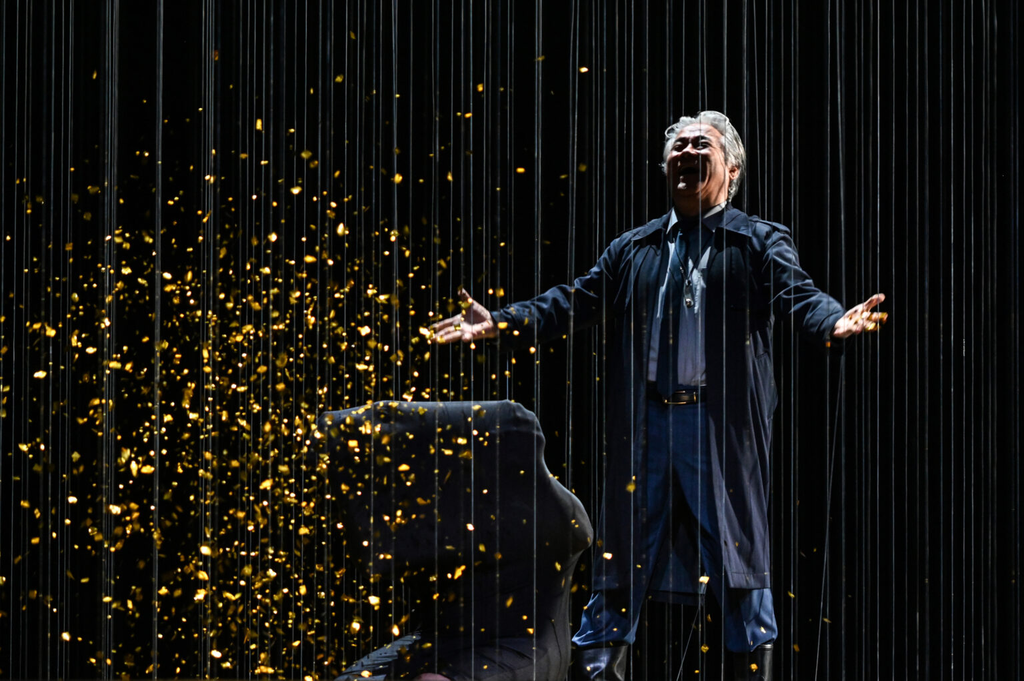

Foto: Hans Jörg Michel

„Das Ganze entfaltet die Faszination eines Psychothrillers, weil Kent Nagano es riskiert, Wagners frühestes von ihm für Bayreuth zugelassenes Werk auf eine ganz eigene Weise, jenseits aller stürmischen Hochsee-Klischees, zu interpretieren.“ urteilt Opern.News über die Musikalische Leitung. Auch von Detlef Brandenburg gibt es bei der Deutschen Bühne online Lob für den Dirigenten: „das Tolle an diesem Abend ist, dass Kent Nagano, der GMD der Staatsoper, mit seinem Dirigat ähnlich eigenwillig auf die metaphorische Finsternis der Inszenierung antwortet.“ Weiter: „Nagano treibt dem „Holländer“ alle konventionelle Wunschkonzert-Verbindlichkeit aus und macht ihn zu einem konsequent quälenden, stockfinsteren Nachtstück mit abgrundtief klaffenden Generalpausen, Ritardandi bis zur Grenze der Erstarrung und Ausbrüchen von wuchtiger Schwere.“ Die Welt ergänzt: „Die vorzüglich aufgelegten Philharmoniker verzahnen sich auf das Engste mit der Szene.“ Christian Strehk fügt in den Kieler Nachrichten hinzu: „Dirigent Kent Nagano achtet auf eine bis ins Letzte durchartikulierte Klangrede.“ Helmut Mauró berichtet in der Süddeutschen Zeitung: „in den Streichern herrscht wüster Gewittersturm. Dirigent Nagano weiß ihn in Zaum zu halten (…)“. Achim Dombrowski ergänzt: „Der Hamburger Musikdirektor Kent Nagano findet zu dieser schwarzen Sichtweise eine einschüchternd kongruente, ungewohnte musikalische Umsetzung. Nagano erarbeitet das Frühwerk Wagners mit der Besinnung auf Herkunft und Einflüsse in der Musik vor Richard Wagner (…). Elemente der deutschen Spieloper, des Liedhaften und der Tanzrhythmik charakterisieren das Klangbild. Diesem Relief in der Partitur wird mit ungewohnt langsamen Tempi nach-gehört.“

Einig ist sich die Presse bei der Qualität der Sänger*innen. Durchweg gibt es Lob für die Besetzung. So berichtet beispielsweise das NDR 90,3 Kulturjournal: „Die Stimmen sind an diesem Abend der wunderbare Kern des Ganzen. Jennifer Holloway, die zum ersten Mal die dem verfluchten Seemann verfallene Senta singt, brilliert nicht nur in ihrer dramatischen Ballade vom „Fliegenden Holländer“. Der Tenor Benjamin Bruns als Erik bringt noch im vierten Rang die Trommelfelle zum Klingeln. Kwangchul Youn singt Sentas Vater Daland so kraftvoll und präzise, dass man jedes Wort versteht.“ Weiter heißt es über die Titelpartie: „Thomas Johannes Mayer singt und spielt den Holländer wunderbar düster“. Die dpa meldet: „beklemmend intensiv gespielt und gesungen von Thomas J. Mayer“. Opern.News schreibt: „Kwangschul Youn ist ein standfester Daland, so wie Peter Hoare seinen Steuermann auch im Chorgetöse profiliert“ und „Erik von Benjamin Bruns ein echter Tenorgenuss. Jennifer Holloway lässt sich als dramatische und doch wohlklingende Senta ebenso auch darstellerisch auf Thalheimers Psychotrip ein, ebenso wie Thomas Johannes Mayer als seine Verzweiflung deutlich akzentuierender Holländer.“ Jan Brachmann lobt in der Frankfurter Allgemeine Zeitung „Kwangchoul Youn als Daland mit seiner vorzüglichen Diktion“ sowie „Peter Hoare als ausgesprochen lyrischen, recht sympathischen Steuermann“ und „Benjamin Bruns als jugendlich loderndem, beinahe schon heldischen Erik und Jennifer Holloways bebende, magmatisch glühende Senta“. Manuel Brug fügt hinzu: „Jennifer Holloway begegnet ihm (Anm.: dem Holländer) als Senta auf Augenhöhe mit klarem Timbre und energetischer dramatischer Intensität“. Christian Strehk schreibt über sie: „Die amerikanische Sopranistin Jennifer Holloway fasziniert über die pausenlosen 140 Spielminuten mit körperlicher und stimmlich flammender Dauerpräsenz von hoher Eindringlichkeit. Wie bei allen Protagonisten ist ihre deutschsprachige Diktion vorbildlich.“

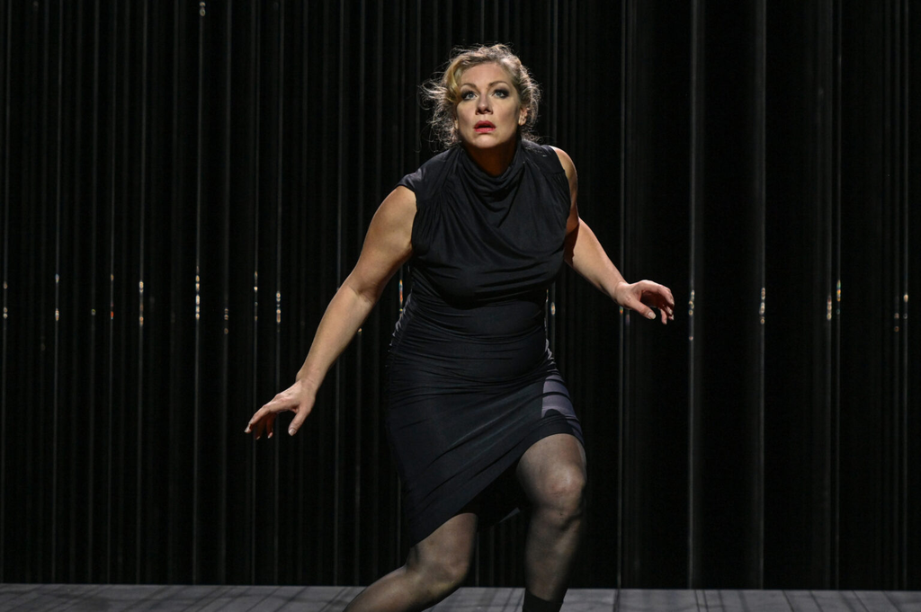

Foto: Hans Jörg Michel

„Publikumsliebling ist aber der Opernchor – unterstützt von Sängerinnen und Sängern aus Kiew“, so Daniel Kaiser. Auch in der Frankfurter Allgemeinen Zeitung gibt es Lob für den Chor: „beim Erwachen der untoten Holländer, wenn der von Eberhard Friedrich einstudierte Chor der Hamburgischen Staatsoper verstärkt wird um Männer aus dem Herrenchor der Oper Kiew (prachtvoll ertüchtigt von Bogdan Plish), da setzt Nagano einen eindrucksvollen musikalischen Hintergrund.“ „Ein besonderes Lob hat sich der vom vielerfahrenen Eberhard Friedrich vorzüglich einstudierte Staatsopern-Chor verdient, der seinen Part mit Präsenz und Präzision herüberbringt“, ist bei der Deutschen Bühne online zu lesen. Weiter heißt es über den Chor der Nationaloper Kyiv: „Beim Sängerkrieg der Mannschaften zu Anfang des dritten Aktes wurde er verstärkt durch Mitglieder des Herrenchores der Nationaloper in Kiew, was erstens eine schöne Geste der Solidarität mit dieser gequälten Stadt in einem gequälten Land ist und zweitens der Seite der Holländer-Matrosen eine vokale Prägnanz einträgt, wie ich sie kaum je erlebt habe.“

Teilen

## Der fliegende Holländer

Sentas Träume zielen aufs Meer: Kommt von dort der Mann, der sie aus dem engen Leben zu Hause befreit? Es beginnt stürmisch, Wagners erste vollgültige Oper malt schon in der Ouvertüre ein grandioses, überwältigendes Bild der Elemente. Das Schicksal des fliegenden Holländers und der Frau, die ihn erlösen soll, vollzieht sich im Brausen der Wellen und des Ozeans. Diese „romantische Oper“ will Grenzen überschreiten – zwischen Tradition und Zukunftsmusik, zwischen Land und Meer, zwischen Konvention und Revolution. Gelungen ist ein packendes Drama, das von einer jungen Frau erzählt, die sich nicht fügen will, die alles auf eine Karte setzt, um ihre Grenzen zu überschreiten, koste es auch das Leben.

[Mehr erfahren…](https://www.staatsoper-hamburg.de/de/spielplan/stueck.php?AuffNr=183598)

[Pressestimmen Carmen — „Eine Sternstunde“](https://blog.staatsoper-hamburg.de/pressestimmen-carmen-eine-sternstunde/)

[Literarisch-Musikalischer Adventskalender 2022](https://blog.staatsoper-hamburg.de/literarisch-musikalischer-adventskalender-2022/)